# Case Study: HR Attrition using Ensemble Techniques

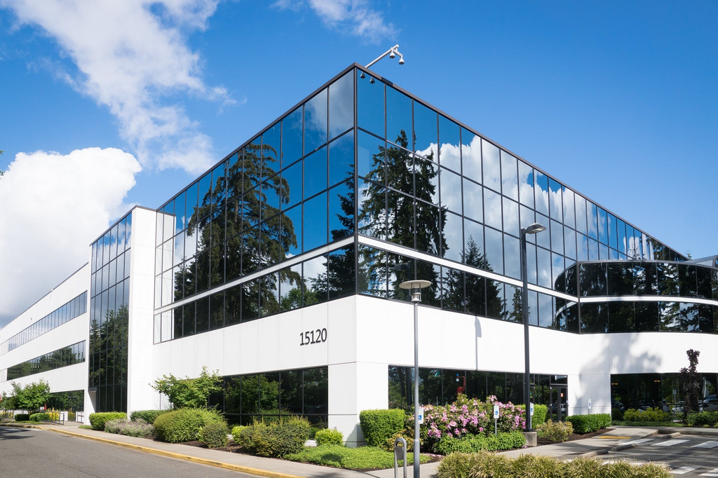

# HR Attrition-2 Case Study

# Business Context

McCurr Consultancy is an MNC that has thousands of employees spread across the globe. The company believes in hiring the best talent available and retaining them for as long as possible. A huge amount of resources is spent on retaining existing employees through various initiatives. The Head of People Operations wants to bring down the cost of retaining employees. For this, he proposes limiting the incentives to only those employees who are at risk of attrition. As a recently hired Data Scientist in the People Operations Department, you have been asked to identify patterns in characteristics of employees who leave the organization. Also, you have to use this information to predict if an employee is at risk of attrition. This information will be used to target them with incentives.

# Business Objective

The primary business objective is to reduce the cost of retaining employees by targeting incentives specifically to those employees who are at risk of attrition. The goal is to identify patterns and factors that contribute to employee attrition and develop a predictive model that can effectively identify employees at risk. By doing so, the company aims to optimize its resources by focusing on retaining individuals who are more likely to leave.

# Data Dictionary

• EmployeeNumber - Employee Identifier

• Attrition - Did the employee attrite?

• Age - Age of the employee • BusinessTravel - Travel commitments for the job

• DailyRate - Data description not available

• Department - Employee Department

• DistanceFromHome - Distance from work to home (in km)

• Education - 1-Below College, 2-College, 3-Bachelor, 4-Master,5-Doctor

• EducationField - Field of Education

• EmployeeCount - Employee Count in a row

• EnvironmentSatisfaction - 1-Low, 2-Medium, 3-High, 4-Very High

• Gender - Employee's gender

• HourlyRate - Data description not available

• Joblnvolvement - 1-Low, 2-Medium, 3-High, 4-Very High

• JobLevel - Level of job (1 to 5)

• JobRole - Job Roles

• JobSatisfaction - 1-Low, 2-Medium, 3-High, 4-Very High • StandardHours - Standard Hours

• StockOptionLevel - Stock Option Level

• TotalWorkingYears - Total years worked

• TrainingTimesLastYear - Number of training attended last year

• WorkLifeBalance - 1-Low, 2-Good, 3-Excellent, 4-Outstanding

• YearsAtCompany - Years at Company

• YearslnCurrentRole - Years in the current role

• YearsSinceLastPromotion - Years since the last promotion

• YearsWithCurrManager - Years with the current manager

# Importing necessary libraries

```python
# Libraries to help with reading and manipulating data
import pandas as pd
import numpy as np


# Libraries to help with data visualization
import matplotlib.pyplot as plt
import seaborn as sns

# split the data into train and test
from sklearn.model_selection import train_test_split


# importing machine learning models for prediction
from sklearn.ensemble import RandomForestClassifier

# to check model performance
from sklearn.metrics import accuracy_score, classification_report, confusion_matrix
```

# Loading the dataset

```python
df = pd.read_csv(r"C:\Users\SONY\Downloads\Dataset - HR Employee Attrition.csv")
```

# Data Overview

The initial steps to get an overview of any dataset is to:

observe the first few rows of the dataset, to check whether the dataset has been loaded properly or not get information about the number of rows and columns in the dataset find out the data types of the columns to ensure that data is stored in the preferred format and the value of each property is as expected. check the statistical summary of the dataset to get an overview of the numerical columns of the data

# Displaying the first few rows of the dataset

```python
df.head()
```

[output not shown]

# Checking the shape of the dataset

```python
df.shape
```

[output not shown]

. The dataset contains information (35 attributes) about 2940 record

# Checking the data types of the columns for the dataset

```python
df.info()
```

[output not shown]

- There are 26 numeric (float and int type) and 9 string (object type) columns in the data.
- The target variable is the Attrition, which is of object type

# Statistical summary of the dataset

```python
df.describe(include="all")
```

[output not shown]

- EmployeeNumber is an ID variable and not useful for predictive modelling.
- Age of the employees range from 18 to 60 years and the average age is 36 years.
- EmployeeCount has only 1 as the value in all the rows and can be dropped as it will not be adding any information to our analysis.
- Standard Hours has only 80 as the value in all the rows and can be dropped as it will not be adding any information to our analysis.
- Hourly rate has a huge range, but we do not know what this variable stands for, yet. The same goes for daily and monthly rates.
- Monthly Income has a high range and the difference in mean and median indicate the presence of outliers.

# Checking for duplicate values

```python
df.duplicated().sum()
```

[output not shown]

- There are no duplicate values in the data

# Checking for missing values

```python
df.isnull().sum()
```

[output not shown]

- There are no missing values in any columns.

# Exploratory Data Analysis (EDA) Summary

1. Measures of central tendency
2. Measures of dispersion
3. Third moment business decision
4. Fourth moment business decision
5. Probability distributions of variables
6. Graphical representations (Histogram, Box plot, Dot plot, Stem & Leaf plot, Bar plot, etc.)

# GRAPHICAL REPRESENTATION

univariate analysis

```python
#EDA using histogram
def plot_histograms(df):
    #select columns with float64 datatype
    float_columns = df.select_dtypes(include="int64")

    # plot histograms for each selected column
    for column in float_columns.columns:
        plt.figure(figsize=(8, 6))
        #plt..hist(df[column].dropna(), bins=20, color='blue', edgecolor='red')
        sns.histplot(df[column])
        plt.title(f'histogram of {column}')
        plt.xlabel(column)
        plt.ylabel('frequency')
        plt.grid(axis='y' , alpha=0.75)
        plt.show()

# Example usage:
plot_histograms(df)
```

[output not shown]

```python
#EDA using Barplot
def plot_bar_plots(df):
    #select columns with object datatype
    object_columns = df.select_dtypes(include="object")

    # plot barplot for each selected column
    for column in object_columns.columns:
        value_counts = df[column].value_counts()
        plt.figure(figsize=(8, 6))
        value_counts.plot(kind= 'bar', color='pink', edgecolor='red')
        plt.title(f'Bar plot of {column}')
        plt.xlabel(column)
        plt.ylabel('count')
        plt.xticks(rotation=45, ha = 'right')
        plt.show()

# Example usage:
plot_bar_plots(df)
```

[output not shown]

```python
#EDA using pieplots
import matplotlib.pyplot as plt

def pie_plots(df):
    # Select columns with object datatype
    object_columns = df.select_dtypes(include="object")

    # Plot barplot for each selected column
    for column in object_columns.columns:
        value_counts = df[column].value_counts()

        # Plot pie chart
        plt.subplot(1, 2, 2)
        plt.pie(value_counts, labels=value_counts.index, autopct='%1.1f%%', startangle=90, colors=['lightblue', 'lightgreen', 'lightcoral', 'lightskyblue'])
        plt.title(f'Pie chart of {column}')

        plt.tight_layout()
        plt.show()

# Example usage:
pie_plots(df)
```

[output not shown]

```python
#EDA using count plot

import seaborn as sns
import matplotlib.pyplot as plt

def plot_count_plots(df):
    # Select columns with object datatype
    object_columns = df.select_dtypes(include="object")

    # Plot countplot for each selected column
    for column in object_columns.columns:
        plt.figure(figsize=(8, 6))
        sns.countplot(data=df, x=column, palette='pastel', edgecolor='red')
        plt.title(f'Count plot of {column}')
        plt.xlabel(column)
        plt.ylabel('Count')
        plt.xticks(rotation=45, ha='right')
        plt.show()

# Example usage:
plot_count_plots(df)
```

[output not shown]

# BIVARIATE ANALYSIS(numerical vs numerical)

```python
import matplotlib.pyplot as plt
import seaborn as sns

def plot_scatter_plots(df):
    # Select columns with numerical datatype
    numerical_columns = df.select_dtypes(include="number")

    # Plot scatterplot for each pair of numerical columns
    for i in range(len(numerical_columns.columns)):
        for j in range(i + 1, len(numerical_columns.columns)):
            plt.figure(figsize=(8, 6))
            sns.scatterplot(x=numerical_columns.iloc[:, i], y=numerical_columns.iloc[:, j], color='blue')
            plt.title(f'Scatter plot of {numerical_columns.columns[i]} vs {numerical_columns.columns[j]}')
            plt.xlabel(numerical_columns.columns[i])
            plt.ylabel(numerical_columns.columns[j])
            plt.show()

# Example usage:
plot_scatter_plots(df)
```

[output not shown]

# BIVARIATE ANALYSIS(categorical vs categorical)

```python
import seaborn as sns
import matplotlib.pyplot as plt

def plot_bivariate_count_plots(df):
    # Select columns with object datatype
    object_columns = df.select_dtypes(include="object")

    # Plot bivariate count plot for each pair of selected columns
    for i in range(len(object_columns.columns) - 1):
        for j in range(i + 1, len(object_columns.columns)):
            plt.figure(figsize=(10, 6))
            sns.countplot(x=object_columns.columns[i], hue=object_columns.columns[j], data=df, palette='pastel')
            plt.title(f'Bivariate Count Plot of {object_columns.columns[i]} vs {object_columns.columns[j]}')
            plt.xlabel(object_columns.columns[i])
            plt.ylabel('count')
            plt.legend(title=object_columns.columns[j])
            plt.xticks(rotation=45, ha='right')
            plt.show()

# Example usage:
plot_bivariate_count_plots(df)
```

[output not shown]

```python
#BIVARIATE ANALYSIS(categorical vs numerical)
```

```python
import matplotlib.pyplot as plt

def plot_bar_plots(df):
    # Select columns with object datatype
    object_columns = df.select_dtypes(include="object")

    # Plot barplot for each selected column
    for column in object_columns.columns:
        value_counts = df[column].value_counts()
        plt.figure(figsize=(8, 6))
        value_counts.plot(kind='bar', color='pink', edgecolor='red')
        plt.title(f'Bar plot of {column}')
        plt.xlabel(column)
        plt.ylabel('count')
        plt.xticks(rotation=45, ha='right')
        plt.show()

        # Bivariate analysis: Pie chart (categorical vs numerical)
        numerical_column = df.select_dtypes(include=["int64", "float64"]).columns[0]
        unique_categories = df[column].unique()

        plt.figure(figsize=(8, 6))
        for category in unique_categories:
            subset = df[df[column] == category]
            category_counts = subset[numerical_column].value_counts()
            plt.pie(category_counts, labels=category_counts.index, autopct='%1.1f%%', startangle=90)
            plt.title(f'{column} vs {numerical_column} for {category}')
            plt.show()

# Example usage:
plot_bar_plots(df)
```

[output not shown]

```python
#Multivariate Analysis

# Visualize the correlation matrix and heatmap
correlation_matrix = df.corr()
plt.figure(figsize=(15, 10))
sns.heatmap(correlation_matrix, annot=True, cmap='coolwarm')
plt.show()
```

[output not shown]

```python
* There are a few variables that are correlated with each other but there are no surprises here.
* Unsurprisingly, TotalWorkingYears is highly correlated to Job Level (i.e., the longer you work the higher job level you achieve).
* HourlyRate, DailyRate, and MonthlyRate are completely uncorrelated with each other which makes it harder to understand what these variables might represent.
* MonthlyIncome is highly correlated to Job Level.
* Age is positively correlated JobLevel and Education (i.e., the older an employee is, the more educated and at a higher job level they are).
* Work-life Balance is correlated with none of the numeric values.
```

[output not shown]

# Data Preparation for Modeling

```python
df.head()
```

```python
# Handle categorical variables using label encoding
from sklearn.preprocessing import LabelEncoder

label_encoder = LabelEncoder()
categorical_cols = df.select_dtypes(include=['object']).columns
for col in categorical_cols:
    df[col] = label_encoder.fit_transform(df[col])
df.head()
```

```python
# Split the data into features (X) and target variable (y)
X = df.drop('Attrition', axis=1)
y = df['Attrition']
X
y
```

```python
# Split the data into training and testing sets
X_train, X_test, y_train, y_test = train_test_split(X, y, test_size=0.2, random_state=42)
print(df.shape,X_train.shape,X_test.shape,y_train.shape,y_test.shape)
```

# Model 1 RANDOM FOREST

```python
# Model 1 RANDOM FOREST
# I decided to do this task with random forest, so I create the object "random_forest"

# initializing the model objects with default parameters
model1 = RandomForestClassifier()
```

```python
# Train the model
model1.fit(X_train, y_train)
```

```python
# Make predictions on the test set
y_pred = model1.predict(X_test)
```

```python
# Evaluate the model
accuracy = accuracy_score(y_test, y_pred)
conf_matrix = confusion_matrix(y_test, y_pred)
classification_rep = classification_report(y_test, y_pred)

print(f"Accuracy: {accuracy}")
print(f"Confusion Matrix:\n{conf_matrix}")
print(f"Classification Report:\n{classification_rep}")
```

[output not shown]

# MODEL 2 - XGBCLASSIFIER

```python
# Model 2 XGB
# Do the same as above but using another classifier algorithm
# initializing the model objects with default parameters
import xgboost as xgb
model2 = xgb.XGBClassifier()
```

```python
# Train the model
model2.fit(X_train, y_train)
```

```python
# Make predictions on the test set
y_pred = model2.predict(X_test)
```

```python
# Evaluate the model
accuracy = accuracy_score(y_test, y_pred)
conf_matrix = confusion_matrix(y_test, y_pred)
classification_rep = classification_report(y_test, y_pred)

print(f"Accuracy: {accuracy}")
print(f"Confusion Matrix:\n{conf_matrix}")
print(f"Classification Report:\n{classification_rep}")
```

[output not shown]